# Introductory H2O Machine Learning Tutorial

#### Prepared for H2O Open Chicago 2016: http://open.h2o.ai/chicago.html

## Setting Up H2O

First step is to download & install the h2o R library The latest version is available by clicking on the R tab here: http://h2o-release.s3.amazonaws.com/h2o/latest_stable.html

You can also just use the install command.

```r
install.packages("h2o")
```

Load the H2O library and start up the H2O cluster locally on your machine

```r
h2o.init(nthreads = -1, #Number of threads -1 means use all cores on your machine
         max_mem_size = "4G")  #max mem size is the maximum memory to allocate to H2O
```

```
H2O is not running yet, starting it now...

Note:  In case of errors look at the following log files:
    /var/folders/qp/1026w_2d5x7_mq4tls6hd_fmyr408v/T//RtmpYTnMGB/h2o_rommelnc_started_from_r.out
    /var/folders/qp/1026w_2d5x7_mq4tls6hd_fmyr408v/T//RtmpYTnMGB/h2o_rommelnc_started_from_r.err
```

```
java version "1.8.0_131"
Java(TM) SE Runtime Environment (build 1.8.0_131-b11)
Java HotSpot(TM) 64-Bit Server VM (build 25.131-b11, mixed mode)
```

```
Starting H2O JVM and connecting: ... Connection successful!

R is connected to the H2O cluster:
    H2O cluster uptime:         4 seconds 192 milliseconds
    H2O cluster version:        3.10.4.6
    H2O cluster version age:    1 month and 7 days
    H2O cluster name:           H2O_started_from_R_rommelnc_bfb198
    H2O cluster total nodes:    1
    H2O cluster total memory:   3.56 GB
    H2O cluster total cores:    4
    H2O cluster allowed cores:  4
    H2O cluster healthy:        TRUE
    H2O Connection ip:          localhost
    H2O Connection port:        54321
    H2O Connection proxy:       NA
    H2O Internal Security:      FALSE
    R Version:                  R version 3.4.0 (2017-04-21)
```

## Loading and Preparing the Data

Next we will import a cleaned up version of the Lending Club “Bad Loans” dataset.

The purpose here is to predict whether a loan will be bad (not repaid to the lender).

The response column, bad_loan, is 1 if the loan was bad, and 0 otherwise.

Import the data.

```r
# loan_csv <- "/Volumes/H2OTOUR/loan.csv"  # modify this for your machine
# Alternatively, you can import the data directly from a URL
loan_csv <- "https://raw.githubusercontent.com/h2oai/app-consumer-loan/master/data/loan.csv"
data <- h2o.importFile(loan_csv)  # 163,987 rows x 15 columns
dim(data)
```

```
[1] 163987     15
```

Since we want to train a binary classification model, we must ensure that the response is coded as a factor.

If the response is 0/1, H2O will assume it’s numeric, which means that H2O will train a regression model instead.

```r
data$bad_loan <- as.factor(data$bad_loan)  #encode the binary repsonse as a factor
h2o.levels(data$bad_loan)  #optional: after encoding, this shows the two factor levels, '0' and '1'
```

```
[1] "0" "1"
```

Partition the data into training, validation and test sets.

```r
splits <- h2o.splitFrame(data = data,
                         ratios = c(0.7, 0.15),  #partition data into 70%, 15%, 15% chunks
                         seed = 1)  #setting a seed will guarantee reproducibility
train <- splits[[1]]
valid <- splits[[2]]
test <- splits[[3]]
```

Take a look at the size of each partition.

Notice that h2o.splitFrame uses approximate splitting not exact splitting (for efficiency) so these are not exactly 70%, 15% and 15% of the total rows.

```r
nrow(train)  # 114908
```

```
[1] 114908
```

```r
nrow(valid) # 24498
```

```
[1] 24498
```

```r
nrow(test)  # 24581
```

```
[1] 24581
```

Identify response and predictor variables.

```r
y <- "bad_loan"
x <- setdiff(names(data), c(y, "int_rate"))  #remove the interest rate column because it's correlated with the outcome
print(x)
```

```
 [1] "loan_amnt"             "term"                  "emp_length"
 [4] "home_ownership"        "annual_inc"            "purpose"
 [7] "addr_state"            "dti"                   "delinq_2yrs"
[10] "revol_util"            "total_acc"             "longest_credit_length"
[13] "verification_status"
```

## Training Models

Now that we have prepared the data, we can train some models.

We will start by training a single model from each of the H2O supervised algos:

1. Generalized Linear Model (GLM);
2. Random Forest (RF);
3. Gradient Boosting Machine (GBM);
4. Deep Learning (DL); and
5. Naive Bayes (NB).

## 1. Let’s start with a basic binomial Generalized Linear Model

By default, h2o.glm uses a regularized, elastic net model.

```r
glm_fit1 <- h2o.glm(x = x,
                    y = y,
                    training_frame = train,
                    model_id = "glm_fit1",
                    family = "binomial")  #similar to R's glm, h2o.glm has the family argument
```

Next we will do some automatic tuning by passing in a validation frame and setting `lambda_search = True`. Since we are training a GLM with regularization, we should try to find the right amount of regularization (to avoid overfitting). The model parameter, `lambda`, controls the amount of regularization in a GLM model and we can find the optimal value for `lambda` automatically by setting `lambda_search = TRUE` and passing in a validation frame (which is used to evaluate model performance using a particular value of lambda).

```r
glm_fit2 <- h2o.glm(x = x,
                    y = y,
                    training_frame = train,
                    model_id = "glm_fit2",
                    validation_frame = valid,
                    family = "binomial",
                    lambda_search = TRUE)
```

Let’s compare the performance of the two GLMs.

```r
glm_perf1 <- h2o.performance(model = glm_fit1,
                             newdata = test)
glm_perf2 <- h2o.performance(model = glm_fit2,
                             newdata = test)
```

Print model performance.

```r
glm_perf1
```

```
H2OBinomialMetrics: glm

MSE:  0.1421533
RMSE:  0.3770322
LogLoss:  0.4510713
Mean Per-Class Error:  0.3696604
AUC:  0.6774447
Gini:  0.3548895
R^2:  0.06392902
Null Deviance:  23672.92
Residual Deviance:  22175.57
AIC:  22281.57

Confusion Matrix (vertical: actual; across: predicted) for F1-optimal threshold:
           0    1    Error         Rate
0      13543 6448 0.322545  =6448/19991
1       1913 2677 0.416776   =1913/4590
Totals 15456 9125 0.340141  =8361/24581

Maximum Metrics: Maximum metrics at their respective thresholds
                        metric threshold    value idx
1                       max f1  0.191905 0.390376 224
2                       max f2  0.118988 0.556182 308
3                 max f0point5  0.276588 0.353820 147
4                 max accuracy  0.496075 0.814369  29
5                max precision  0.744968 1.000000   0
6                   max recall  0.001227 1.000000 399
7              max specificity  0.744968 1.000000   0
8             max absolute_mcc  0.198577 0.210837 216
9   max min_per_class_accuracy  0.180219 0.629133 236
10 max mean_per_class_accuracy  0.191905 0.630340 224

Gains/Lift Table: Extract with `h2o.gainsLift(<model>, <data>)` or `h2o.gainsLift(<model>, valid=<T/F>, xval=<T/F>)`
```

```r
glm_perf2
```

```
H2OBinomialMetrics: glm

MSE:  0.1421964
RMSE:  0.3770893
LogLoss:  0.4512101
Mean Per-Class Error:  0.3711143
AUC:  0.6772
Gini:  0.3544
R^2:  0.06364537
Null Deviance:  23672.92
Residual Deviance:  22182.39
AIC:  22282.39

Confusion Matrix (vertical: actual; across: predicted) for F1-optimal threshold:
           0    1    Error         Rate
0      13511 6480 0.324146  =6480/19991
1       1919 2671 0.418083   =1919/4590
Totals 15430 9151 0.341687  =8399/24581

Maximum Metrics: Maximum metrics at their respective thresholds
                        metric threshold    value idx
1                       max f1  0.191608 0.388764 222
2                       max f2  0.120780 0.555724 304
3                 max f0point5  0.256503 0.352561 157
4                 max accuracy  0.471382 0.814694  35
5                max precision  0.735936 1.000000   0
6                   max recall  0.000787 1.000000 399
7              max specificity  0.735936 1.000000   0
8             max absolute_mcc  0.196888 0.208974 216
9   max min_per_class_accuracy  0.180456 0.627132 234
10 max mean_per_class_accuracy  0.185089 0.629198 229

Gains/Lift Table: Extract with `h2o.gainsLift(<model>, <data>)` or `h2o.gainsLift(<model>, valid=<T/F>, xval=<T/F>)`
```

Instead of printing the entire model performance metrics object, it is probably easier to print just the metric that you are interested in comparing.

Retreive test set AUC.

```r
h2o.auc(glm_perf1)
```

```
[1] 0.6774447
```

```r
h2o.auc(glm_perf2)
```

```
[1] 0.6772
```

Compare test AUC to the training AUC and validation AUC.

```r
h2o.auc(glm_fit2, train = TRUE)
```

```
[1] 0.6735941
```

```r
h2o.auc(glm_fit2, valid = TRUE)
```

```
[1] 0.6754209
```

```r
glm_fit2@model$validation_metrics
```

```
H2OBinomialMetrics: glm
** Reported on validation data. **

MSE:  0.1420118
RMSE:  0.3768446
LogLoss:  0.4510773
Mean Per-Class Error:  0.3702869
AUC:  0.6754209
Gini:  0.3508418
R^2:  0.05970267
Null Deviance:  23495.19
Residual Deviance:  22100.99
AIC:  22200.99

Confusion Matrix (vertical: actual; across: predicted) for F1-optimal threshold:
           0    1    Error         Rate
0      13569 6387 0.320054  =6387/19956
1       1910 2632 0.420520   =1910/4542
Totals 15479 9019 0.338681  =8297/24498

Maximum Metrics: Maximum metrics at their respective thresholds
                        metric threshold    value idx
1                       max f1  0.192913 0.388172 216
2                       max f2  0.116778 0.555145 312
3                 max f0point5  0.288580 0.343075 133
4                 max accuracy  0.487151 0.815209  29
5                max precision  0.575981 0.695652   9
6                   max recall  0.004354 1.000000 398
7              max specificity  0.712974 0.999950   0
8             max absolute_mcc  0.192913 0.209037 216
9   max min_per_class_accuracy  0.180463 0.627581 232
10 max mean_per_class_accuracy  0.192913 0.629713 216

Gains/Lift Table: Extract with `h2o.gainsLift(<model>, <data>)` or `h2o.gainsLift(<model>, valid=<T/F>, xval=<T/F>)`
```

## 2. Random Forest

H2O’s Random Forest (RF) implements a distributed version of the standard Random Forest algorithm and variable importance measures.

### First we will train a basic Random Forest model with default parameters.

The Random Forest model will infer the response distribution from the response encoding.

A seed is required for reproducibility.

```r
rf_fit1 <- h2o.randomForest(x = x,
                            y = y,
                            training_frame = train,
                            model_id = "rf_fit1",
                            seed = 1)
```

### Next we will increase the number of trees used in the forest by setting `ntrees = 100`.

The default number of trees in an H2O Random Forest is 50, so this RF will be twice as big as the default. Usually increasing the number of trees in a RF will increase performance as well. Unlike Gradient Boosting Machines (GBMs), Random Forests are fairly resistant (although not free from) overfitting.

See the GBM example below for additional guidance on preventing overfitting using H2O’s early stopping functionality.

```r
rf_fit2 <- h2o.randomForest(x = x,
                            y = y,
                            training_frame = train,
                            model_id = "rf_fit2",
                            #validation_frame = valid,  #only used if stopping_rounds > 0
                            ntrees = 100,
                            seed = 1)
```

Let’s compare the performance of the two RFs.

```r
rf_perf1 <- h2o.performance(model = rf_fit1,
                            newdata = test)
rf_perf2 <- h2o.performance(model = rf_fit2,
                            newdata = test)
```

Print model performance.

```r
rf_perf1
```

```
H2OBinomialMetrics: drf

MSE:  0.1438229
RMSE:  0.37924
LogLoss:  0.4569658
Mean Per-Class Error:  0.3802215
AUC:  0.6648373
Gini:  0.3296746

Confusion Matrix (vertical: actual; across: predicted) for F1-optimal threshold:
           0     1    Error         Rate
0      11984  8007 0.400530  =8007/19991
1       1652  2938 0.359913   =1652/4590
Totals 13636 10945 0.392946  =9659/24581

Maximum Metrics: Maximum metrics at their respective thresholds
                        metric threshold    value idx
1                       max f1  0.179535 0.378243 244
2                       max f2  0.101166 0.550517 324
3                 max f0point5  0.290318 0.340770 154
4                 max accuracy  0.512740 0.813515  43
5                max precision  0.742525 0.666667   2
6                   max recall  0.007468 1.000000 396
7              max specificity  0.798990 0.999950   0
8             max absolute_mcc  0.222285 0.193695 206
9   max min_per_class_accuracy  0.184768 0.616778 239
10 max mean_per_class_accuracy  0.179535 0.619778 244

Gains/Lift Table: Extract with `h2o.gainsLift(<model>, <data>)` or `h2o.gainsLift(<model>, valid=<T/F>, xval=<T/F>)`
```

```r
rf_perf2
```

```
H2OBinomialMetrics: drf

MSE:  0.1429724
RMSE:  0.378117
LogLoss:  0.4538945
Mean Per-Class Error:  0.375031
AUC:  0.6701498
Gini:  0.3402997

Confusion Matrix (vertical: actual; across: predicted) for F1-optimal threshold:
           0     1    Error         Rate
0      12087  7904 0.395378  =7904/19991
1       1628  2962 0.354684   =1628/4590
Totals 13715 10866 0.387779  =9532/24581

Maximum Metrics: Maximum metrics at their respective thresholds
                        metric threshold    value idx
1                       max f1  0.180433 0.383282 240
2                       max f2  0.107164 0.550293 316
3                 max f0point5  0.297675 0.348490 141
4                 max accuracy  0.567151 0.813637  20
5                max precision  0.669570 0.625000   4
6                   max recall  0.010919 1.000000 396
7              max specificity  0.709810 0.999950   0
8             max absolute_mcc  0.239435 0.203692 187
9   max min_per_class_accuracy  0.185317 0.621680 235
10 max mean_per_class_accuracy  0.180433 0.624969 240

Gains/Lift Table: Extract with `h2o.gainsLift(<model>, <data>)` or `h2o.gainsLift(<model>, valid=<T/F>, xval=<T/F>)`
```

Retreive test set AUC.

```r
h2o.auc(rf_perf1)
```

```
[1] 0.6648373
```

```r
h2o.auc(rf_perf2)
```

```
[1] 0.6701498
```

### Cross-validate performance

Rather than using held-out test set to evaluate model performance, a user may wish to estimate model performance using cross-validation. Using the RF algorithm (with default model parameters) as an example, we demonstrate how to perform k-fold cross-validation using H2O. No custom code or loops are required, you simply specify the number of desired folds in the nfolds argument.

```r
rf_fit3 <- h2o.randomForest(x = x,
                            y = y,
                            training_frame = train,
                            model_id = "rf_fit3",
                            seed = 1,
                            nfolds = 5)
```

To evaluate the cross-validated AUC, do the following:

```r
h2o.auc(rf_fit3, xval = TRUE)
```

```
[1] 0.6585138
```

## 3. Gradient Boosting Machine

H2O’s Gradient Boosting Machine (GBM) offers a Stochastic GBM, which can increase performance quite a bit compared to the original GBM implementation.

### Now we will train a basic GBM model.

The GBM model will infer the response distribution from the response encoding if not specified explicitly through the `distribution` argument. A seed is required for reproducibility.

```r
gbm_fit1 <- h2o.gbm(x = x,
                    y = y,
                    training_frame = train,
                    model_id = "gbm_fit1",
                    seed = 1)
```

### Next we will increase the number of trees used in the GBM by setting `ntrees=500`.

The default number of trees in an H2O GBM is 50, so this GBM will trained using ten times the default. Increasing the number of trees in a GBM is one way to increase performance of the model, however, you have to be careful not to overfit your model to the training data by using too many trees. To automatically find the optimal number of trees, you must use H2O’s early stopping functionality. This example will not do that, however, the following example will.

```r
gbm_fit2 <- h2o.gbm(x = x,
                    y = y,
                    training_frame = train,
                    model_id = "gbm_fit2",
                    #validation_frame = valid,  #only used if stopping_rounds > 0
                    ntrees = 500,
                    seed = 1)
```

### We will again set `ntrees = 500`, however, this time we will use early stopping

We will again set `ntrees = 500`, however, this time we will use early stopping in order to prevent overfitting (from too many trees). All of H2O’s algorithms have early stopping available, however early stopping is not enabled by default (with the exception of Deep Learning).

There are several parameters that should be used to control early stopping. The three that are common to all the algorithms are: `stopping_rounds`, `stopping_metric` and `stopping_tolerance`.

The stopping metric is the metric by which you’d like to measure performance, and so we will choose AUC here. The `score_tree_interval` is a parameter specific to the Random Forest model and the GBM.

Setting `score_tree_interval = 5` will score the model after every five trees. The parameters we have set below specify that the model will stop training after there have been three scoring intervals where the AUC has not increased more than 0.0005. Since we have specified a validation frame, the stopping tolerance will be computed on validation AUC rather than training AUC.

```r
gbm_fit3 <- h2o.gbm(x = x,
                    y = y,
                    training_frame = train,
                    model_id = "gbm_fit3",
                    validation_frame = valid,  #only used if stopping_rounds > 0
                    ntrees = 500,
                    score_tree_interval = 5,      #used for early stopping
                    stopping_rounds = 3,          #used for early stopping
                    stopping_metric = "AUC",      #used for early stopping
                    stopping_tolerance = 0.0005,  #used for early stopping
                    seed = 1)
```

### Let’s compare the performance of the two GBMs.

```r
gbm_perf1 <- h2o.performance(model = gbm_fit1,
                             newdata = test)
gbm_perf2 <- h2o.performance(model = gbm_fit2,
                             newdata = test)
gbm_perf3 <- h2o.performance(model = gbm_fit3,
                             newdata = test)
```

Print model performance.

```r
gbm_perf1
```

```
H2OBinomialMetrics: gbm

MSE:  0.1414794
RMSE:  0.3761375
LogLoss:  0.4484938
Mean Per-Class Error:  0.3686212
AUC:  0.6838852
Gini:  0.3677703

Confusion Matrix (vertical: actual; across: predicted) for F1-optimal threshold:
           0    1    Error         Rate
0      13014 6977 0.349007  =6977/19991
1       1782 2808 0.388235   =1782/4590
Totals 14796 9785 0.356332  =8759/24581

Maximum Metrics: Maximum metrics at their respective thresholds
                        metric threshold    value idx
1                       max f1  0.181359 0.390678 241
2                       max f2  0.108593 0.560109 331
3                 max f0point5  0.285114 0.356192 145
4                 max accuracy  0.509850 0.814369  28
5                max precision  0.601699 0.636364  10
6                   max recall  0.039117 1.000000 398
7              max specificity  0.719189 0.999950   0
8             max absolute_mcc  0.220329 0.215310 200
9   max min_per_class_accuracy  0.175999 0.628933 247
10 max mean_per_class_accuracy  0.170196 0.632415 254

Gains/Lift Table: Extract with `h2o.gainsLift(<model>, <data>)` or `h2o.gainsLift(<model>, valid=<T/F>, xval=<T/F>)`
```

```r
gbm_perf2
```

```
H2OBinomialMetrics: gbm

MSE:  0.1416343
RMSE:  0.3763434
LogLoss:  0.4486982
Mean Per-Class Error:  0.3670576
AUC:  0.6840778
Gini:  0.3681556

Confusion Matrix (vertical: actual; across: predicted) for F1-optimal threshold:
           0    1    Error         Rate
0      13634 6357 0.317993  =6357/19991
1       1910 2680 0.416122   =1910/4590
Totals 15544 9037 0.336317  =8267/24581

Maximum Metrics: Maximum metrics at their respective thresholds
                        metric threshold    value idx
1                       max f1  0.189301 0.393337 237
2                       max f2  0.097169 0.558981 336
3                 max f0point5  0.278376 0.359450 164
4                 max accuracy  0.526309 0.814287  40
5                max precision  0.901295 1.000000   0
6                   max recall  0.018504 1.000000 398
7              max specificity  0.901295 1.000000   0
8             max absolute_mcc  0.230675 0.217482 201
9   max min_per_class_accuracy  0.175797 0.630719 251
10 max mean_per_class_accuracy  0.156837 0.633735 271

Gains/Lift Table: Extract with `h2o.gainsLift(<model>, <data>)` or `h2o.gainsLift(<model>, valid=<T/F>, xval=<T/F>)`
```

```r
gbm_perf3
```

```
H2OBinomialMetrics: gbm

MSE:  0.1414934
RMSE:  0.376156
LogLoss:  0.4483155
Mean Per-Class Error:  0.3674871
AUC:  0.6844529
Gini:  0.3689057

Confusion Matrix (vertical: actual; across: predicted) for F1-optimal threshold:
           0    1    Error         Rate
0      13717 6274 0.313841  =6274/19991
1       1933 2657 0.421133   =1933/4590
Totals 15650 8931 0.333876  =8207/24581

Maximum Metrics: Maximum metrics at their respective thresholds
                        metric threshold    value idx
1                       max f1  0.190775 0.393018 234
2                       max f2  0.110736 0.559835 320
3                 max f0point5  0.286344 0.356467 153
4                 max accuracy  0.511864 0.814532  39
5                max precision  0.797620 1.000000   0
6                   max recall  0.026576 1.000000 397
7              max specificity  0.797620 1.000000   0
8             max absolute_mcc  0.231330 0.217642 197
9   max min_per_class_accuracy  0.176467 0.632462 249
10 max mean_per_class_accuracy  0.175308 0.633510 250

Gains/Lift Table: Extract with `h2o.gainsLift(<model>, <data>)` or `h2o.gainsLift(<model>, valid=<T/F>, xval=<T/F>)`
```

Retreive test set AUC.

```r
h2o.auc(gbm_perf1)
```

```
[1] 0.6838852
```

```r
h2o.auc(gbm_perf2)
```

```
[1] 0.6840778
```

```r
h2o.auc(gbm_perf3)
```

```
[1] 0.6844529
```

To examine the scoring history, use the `scoring_history` method on a trained model.

If `score_tree_interval` is not specified, it will score at various intervals, as we can see for `h2o.scoreHistory()` below. However, regular 5-tree intervals are used for `h2o.scoreHistory()`.

The `gbm_fit2` was trained only using a training set (no validation set), so the scoring history is calculated for training set performance metrics only.

```r
h2o.scoreHistory(gbm_fit2)
```

```
Scoring History:
             timestamp   duration number_of_trees training_rmse training_logloss
1  2017-06-03 07:27:50  0.021 sec               0       0.38563          0.47403
2  2017-06-03 07:27:51  0.900 sec               1       0.38370          0.46913
3  2017-06-03 07:27:51  1.504 sec               2       0.38206          0.46512
4  2017-06-03 07:27:51  1.875 sec               3       0.38069          0.46184
5  2017-06-03 07:27:52  2.134 sec               4       0.37954          0.45912
6  2017-06-03 07:27:52  2.552 sec               5       0.37853          0.45676
7  2017-06-03 07:27:53  3.225 sec               6       0.37763          0.45468
8  2017-06-03 07:27:53  3.666 sec               7       0.37685          0.45291
9  2017-06-03 07:27:54  4.113 sec               8       0.37618          0.45135
10 2017-06-03 07:27:58  8.238 sec              49       0.36709          0.43025
11 2017-06-03 07:28:08 18.417 sec             256       0.36129          0.41770
12 2017-06-03 07:28:16 26.187 sec             500       0.36129          0.41770
   training_auc training_lift training_classification_error
1       0.50000       1.00000                       0.81825
2       0.65779       2.68330                       0.40069
3       0.66583       2.79399                       0.33325
4       0.66851       2.97100                       0.34475
5       0.67011       2.97544                       0.33180
6       0.67363       3.04518                       0.32313
7       0.67523       3.10037                       0.31219
8       0.67677       3.15225                       0.32471
9       0.67854       3.18148                       0.32561
10      0.71526       3.68408                       0.30092
11      0.74024       4.25823                       0.27842
12      0.74024       4.25823                       0.27842
```

Since we used a validation set in `gbm_fit3`, both training and validation performance metrics are stored in the scoring history object. Take a look at the validation AUC to observe that the correct stopping tolerance was enforced.

```r
h2o.scoreHistory(gbm_fit3)
```

```
Scoring History:
             timestamp   duration number_of_trees training_rmse training_logloss
1  2017-06-03 07:29:04  0.007 sec               0       0.38563          0.47403
2  2017-06-03 07:29:04  0.478 sec               5       0.37853          0.45676
3  2017-06-03 07:29:05  1.393 sec              10       0.37508          0.44884
4  2017-06-03 07:29:06  2.290 sec              15       0.37307          0.44424
5  2017-06-03 07:29:07  3.268 sec              20       0.37152          0.44060
6  2017-06-03 07:29:08  4.617 sec              25       0.37041          0.43800
7  2017-06-03 07:29:10  6.002 sec              30       0.36947          0.43578
8  2017-06-03 07:29:11  7.338 sec              35       0.36877          0.43410
9  2017-06-03 07:29:12  8.906 sec              40       0.36808          0.43252
10 2017-06-03 07:29:14 10.724 sec              45       0.36748          0.43116
11 2017-06-03 07:29:16 12.596 sec              50       0.36699          0.43002
12 2017-06-03 07:29:18 14.518 sec              55       0.36651          0.42899
13 2017-06-03 07:29:20 16.485 sec              60       0.36607          0.42801
```

[output cut: 49 more lines]

Look at scoring history for third GBM model.

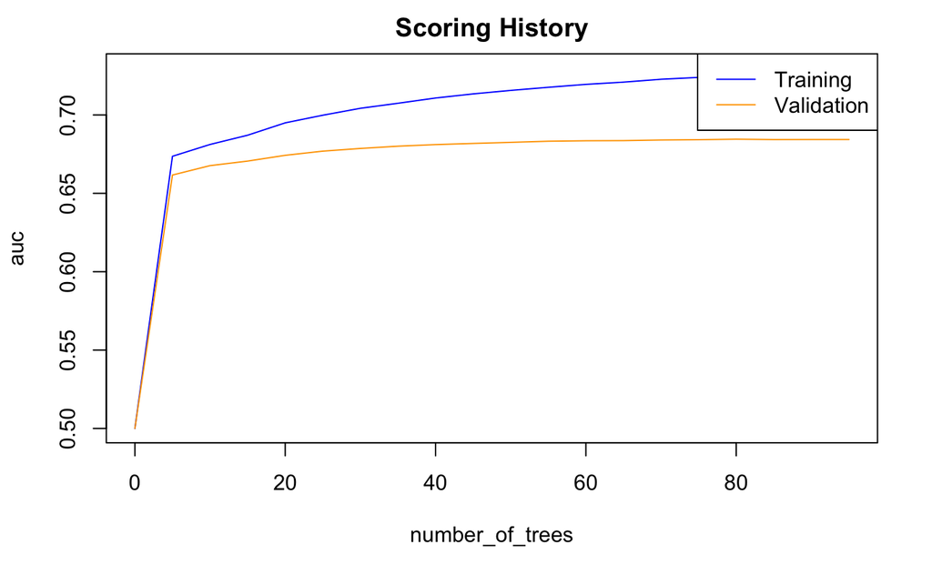

```r
plot(gbm_fit3,
     timestep = "number_of_trees",
     metric = "AUC")
```

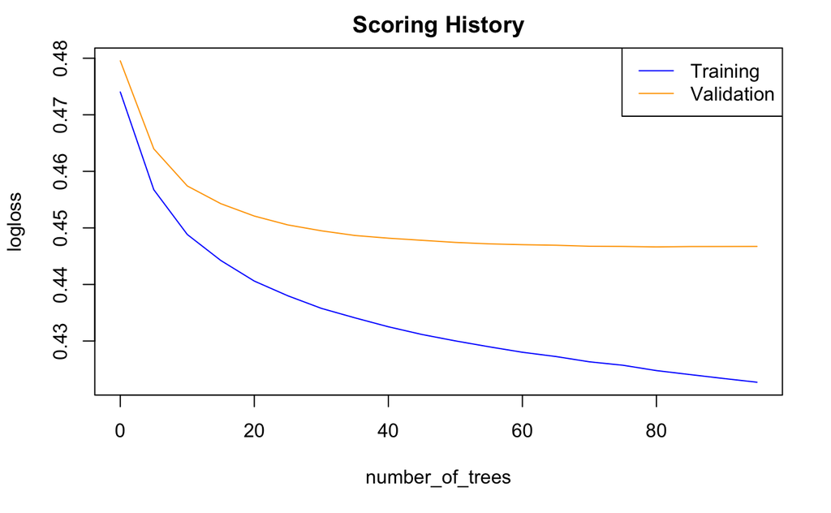

```r
plot(gbm_fit3,
     timestep = "number_of_trees",
     metric = "logloss")
```

## 4. Deep Learning

H2O’s Deep Learning algorithm is a multilayer feed-forward artificial neural network.

It can also be used to train an autoencoder. In this example we will train a standard supervised prediction model.

### Train a default DL.

First we will train a basic DL model with default parameters. The DL model will infer the response distribution from the response encoding if it is not specified explicitly through the `distribution` argument.

H2O’s DL will not be reproducible if it is run on more than a single core, so in this example, the performance metrics below may vary slightly from what you see on your machine.

In H2O’s DL, early stopping is enabled by default, so below, it will use the training set and default stopping parameters to perform early stopping.

```r
dl_fit1 <- h2o.deeplearning(x = x,
                            y = y,
                            training_frame = train,
                            model_id = "dl_fit1",
                            seed = 1)
```

### Train a DL with new architecture and more epochs.

Next we will increase the number of epochs used in the GBM by setting `epochs=20` (the default is 10).

Increasing the number of epochs in a deep neural net may increase performance of the model, however, you have to be careful not to overfit your model to your training data. To automatically find the optimal number of epochs, you must use H2O’s early stopping functionality. Unlike the rest of the H2O algorithms, H2O’s DL will use early stopping by default, so for comparison we will first turn off early stopping. We do this in the next example by setting `stopping_rounds=0`.

```r
dl_fit2 <- h2o.deeplearning(x = x,
                            y = y,
                            training_frame = train,
                            model_id = "dl_fit2",
                            #validation_frame = valid,  #only used if stopping_rounds > 0
                            epochs = 20,
                            hidden= c(10,10),
                            stopping_rounds = 0,  # disable early stopping
                            seed = 1)
```

### Train a DL with early stopping

This example will use the same model parameters as `dl_fit2`. This time, we will turn on early stopping and specify the stopping criterion. We will also pass a validation set, as is recommended for early stopping.

```r
dl_fit3 <- h2o.deeplearning(x = x,
                            y = y,
                            training_frame = train,
                            model_id = "dl_fit3",
                            validation_frame = valid,  #in DL, early stopping is on by default
                            epochs = 20,
                            hidden = c(10,10),
                            score_interval = 1,           #used for early stopping
                            stopping_rounds = 3,          #used for early stopping
                            stopping_metric = "AUC",      #used for early stopping
                            stopping_tolerance = 0.0005,  #used for early stopping
                            seed = 1)
```

Let’s compare the performance of the three DL models

```r
dl_perf1 <- h2o.performance(model = dl_fit1,
                            newdata = test)
dl_perf2 <- h2o.performance(model = dl_fit2,
                            newdata = test)
dl_perf3 <- h2o.performance(model = dl_fit3,
                            newdata = test)
```

Print model performance

```r
dl_perf1
```

```
H2OBinomialMetrics: deeplearning

MSE:  0.1426156
RMSE:  0.3776448
LogLoss:  0.4529839
Mean Per-Class Error:  0.3693743
AUC:  0.6783389
Gini:  0.3566778

Confusion Matrix (vertical: actual; across: predicted) for F1-optimal threshold:
           0     1    Error         Rate
0      12544  7447 0.372518  =7447/19991
1       1681  2909 0.366231   =1681/4590
Totals 14225 10356 0.371344  =9128/24581

Maximum Metrics: Maximum metrics at their respective thresholds
                        metric threshold    value idx
1                       max f1  0.159392 0.389268 252
2                       max f2  0.084418 0.558033 329
3                 max f0point5  0.277132 0.349087 159
4                 max accuracy  0.470811 0.814084  54
5                max precision  0.709663 0.833333   8
6                   max recall  0.002941 1.000000 399
7              max specificity  0.836859 0.999950   0
8             max absolute_mcc  0.198098 0.208306 218
9   max min_per_class_accuracy  0.160484 0.630184 251
10 max mean_per_class_accuracy  0.150932 0.630828 260

Gains/Lift Table: Extract with `h2o.gainsLift(<model>, <data>)` or `h2o.gainsLift(<model>, valid=<T/F>, xval=<T/F>)`
```

```r
dl_perf2
```

```
H2OBinomialMetrics: deeplearning

MSE:  0.1436486
RMSE:  0.3790101
LogLoss:  0.455549
Mean Per-Class Error:  0.3702819
AUC:  0.6755412
Gini:  0.3510823

Confusion Matrix (vertical: actual; across: predicted) for F1-optimal threshold:
           0     1    Error         Rate
0      12499  7492 0.374769  =7492/19991
1       1679  2911 0.365795   =1679/4590
Totals 14178 10403 0.373093  =9171/24581

Maximum Metrics: Maximum metrics at their respective thresholds
                        metric threshold    value idx
1                       max f1  0.223121 0.388315 220
2                       max f2  0.134755 0.553692 310
3                 max f0point5  0.365542 0.350548 104
4                 max accuracy  0.520884 0.814491  21
5                max precision  0.743425 1.000000   0
6                   max recall  0.009644 1.000000 397
7              max specificity  0.743425 1.000000   0
8             max absolute_mcc  0.259533 0.210340 185
9   max min_per_class_accuracy  0.224022 0.627532 219
10 max mean_per_class_accuracy  0.222179 0.629785 221

Gains/Lift Table: Extract with `h2o.gainsLift(<model>, <data>)` or `h2o.gainsLift(<model>, valid=<T/F>, xval=<T/F>)`
```

```r
dl_perf3
```

```
H2OBinomialMetrics: deeplearning

MSE:  0.1422133
RMSE:  0.3771118
LogLoss:  0.4504999
Mean Per-Class Error:  0.36753
AUC:  0.6818078
Gini:  0.3636155

Confusion Matrix (vertical: actual; across: predicted) for F1-optimal threshold:
           0    1    Error         Rate
0      13197 6794 0.339853  =6794/19991
1       1814 2776 0.395207   =1814/4590
Totals 15011 9570 0.350189  =8608/24581

Maximum Metrics: Maximum metrics at their respective thresholds
                        metric threshold    value idx
1                       max f1  0.219825 0.392090 208
2                       max f2  0.133329 0.559302 300
3                 max f0point5  0.316820 0.355616 127
4                 max accuracy  0.496830 0.814816  20
5                max precision  0.530115 0.661765   7
6                   max recall  0.018278 1.000000 397
7              max specificity  0.553944 0.999850   0
8             max absolute_mcc  0.235856 0.213733 195
9   max min_per_class_accuracy  0.209942 0.631184 218
10 max mean_per_class_accuracy  0.219825 0.632470 208

Gains/Lift Table: Extract with `h2o.gainsLift(<model>, <data>)` or `h2o.gainsLift(<model>, valid=<T/F>, xval=<T/F>)`
```

Retreive test set AUC

```r
h2o.auc(dl_perf1)
```

```
[1] 0.6783389
```

```r
h2o.auc(dl_perf2)
```

```
[1] 0.6755412
```

```r
h2o.auc(dl_perf3)
```

```
[1] 0.6818078
```

Scoring history

```r
h2o.scoreHistory(dl_fit3)
```

```
Scoring History:
            timestamp   duration training_speed   epochs iterations        samples
1 2017-06-03 07:33:05  0.000 sec                 0.00000          0       0.000000
2 2017-06-03 07:33:05  0.771 sec 250959 obs/sec  0.87142          1  100133.000000
3 2017-06-03 07:33:08  2.994 sec 325829 obs/sec  6.95849          8  799586.000000
4 2017-06-03 07:33:09  4.715 sec 345502 obs/sec 12.18043         14 1399629.000000
5 2017-06-03 07:33:11  5.977 sec 365007 obs/sec 16.53378         19 1899864.000000
6 2017-06-03 07:33:12  6.966 sec 377697 obs/sec 20.01757         23 2300179.000000
  training_rmse training_logloss training_auc training_lift training_classification_error
1
2       0.38016          0.45943      0.66044       3.26579                       0.37561
3       0.37635          0.44903      0.67755       2.55820                       0.35841
4       0.38149          0.46404      0.67584       2.55820                       0.43790
5       0.37574          0.44714      0.68209       2.77592                       0.41009
6       0.37622          0.44812      0.68432       3.04807                       0.38451
  validation_rmse validation_logloss validation_auc validation_lift
1
2         0.38000            0.45844        0.66415         2.59776
3         0.37645            0.44953        0.67781         2.44366
4         0.38170            0.46504        0.67589         2.72985
5         0.37639            0.44881        0.67908         2.79590
6         0.37722            0.45070        0.67920         2.61978
  validation_classification_error
1
2                         0.37509
3                         0.35452
4                         0.37668
5                         0.33946
6                         0.36072
```

Look at scoring history for third DL model

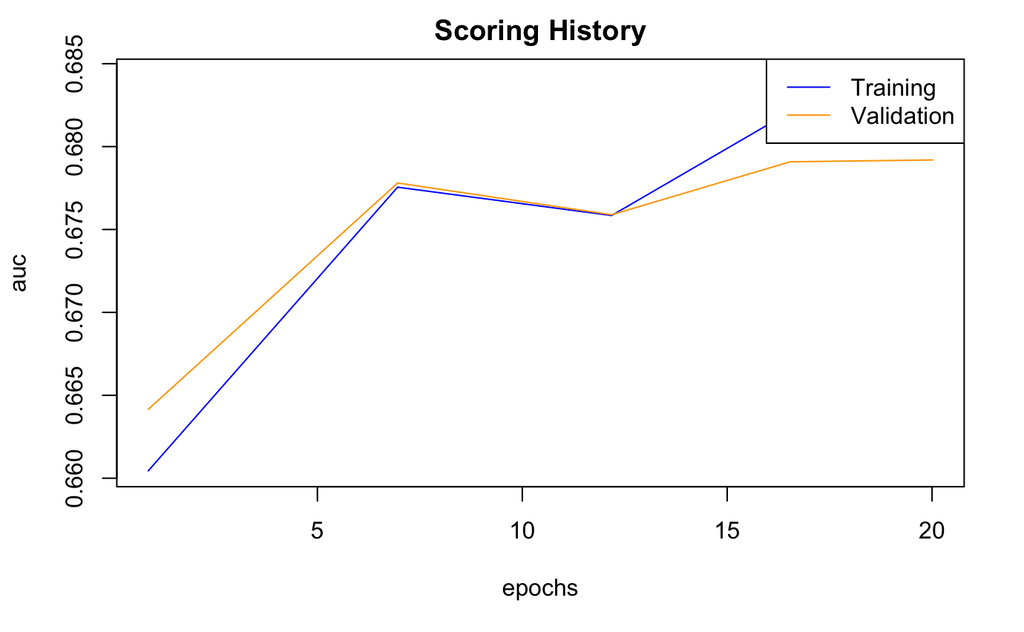

```r
plot(dl_fit3,
     timestep = "epochs",
     metric = "AUC")
```

## 5. Naive Bayes model

The Naive Bayes (NB) algorithm does not usually beat an algorithm like a Random Forest or GBM, however it is still a popular algorithm, especially in the text domain (when your input is text encoded as “Bag of Words”, for example). The Naive Bayes algorithm is for binary or multiclass classification problems only, not regression. Therefore, your response must be a factor instead of a numeric.

### First we will train a basic NB model with default parameters.

```r
nb_fit1 <- h2o.naiveBayes(x = x,
                          y = y,
                          training_frame = train,
                          model_id = "nb_fit1")
```

### Train a NB model with Laplace Smoothing

One of the few tunable model parameters for the Naive Bayes algorithm is the amount of Laplace smoothing. The H2O Naive Bayes model will not use any Laplace smoothing by default.

```r
nb_fit2 <- h2o.naiveBayes(x = x,
                          y = y,
                          training_frame = train,
                          model_id = "nb_fit2",
                          laplace = 6)
```

Let’s compare the performance of the two NB models

```r
nb_perf1 <- h2o.performance(model = nb_fit1,
                            newdata = test)
nb_perf2 <- h2o.performance(model = nb_fit2,
                            newdata = test)
```

Print model performance

```r
nb_perf1
```

```
H2OBinomialMetrics: naivebayes

MSE:  0.1497243
RMSE:  0.3869422
LogLoss:  0.4893385
Mean Per-Class Error:  0.3906253
AUC:  0.6513648
Gini:  0.3027295

Confusion Matrix (vertical: actual; across: predicted) for F1-optimal threshold:
           0    1    Error         Rate
0      13210 6781 0.339203  =6781/19991
1       2029 2561 0.442048   =2029/4590
Totals 15239 9342 0.358407  =8810/24581

Maximum Metrics: Maximum metrics at their respective thresholds
                        metric threshold    value idx
1                       max f1  0.226439 0.367643 238
2                       max f2  0.089985 0.545552 348
3                 max f0point5  0.340728 0.335986 168
4                 max accuracy  0.999554 0.812945   0
5                max precision  0.576572 0.431457  69
6                   max recall  0.000172 1.000000 399
7              max specificity  0.999554 0.999550   0
8             max absolute_mcc  0.287082 0.188613 199
9   max min_per_class_accuracy  0.207260 0.603972 252
10 max mean_per_class_accuracy  0.247332 0.609423 224

Gains/Lift Table: Extract with `h2o.gainsLift(<model>, <data>)` or `h2o.gainsLift(<model>, valid=<T/F>, xval=<T/F>)`
```

```r
nb_perf2
```

```
H2OBinomialMetrics: naivebayes

MSE:  0.1496746
RMSE:  0.3868781
LogLoss:  0.4892283
Mean Per-Class Error:  0.3899434
AUC:  0.6514341
Gini:  0.3028682

Confusion Matrix (vertical: actual; across: predicted) for F1-optimal threshold:
           0    1    Error         Rate
0      14043 5948 0.297534  =5948/19991
1       2214 2376 0.482353   =2214/4590
Totals 16257 8324 0.332045  =8162/24581

Maximum Metrics: Maximum metrics at their respective thresholds
                        metric threshold    value idx
1                       max f1  0.243000 0.367973 226
2                       max f2  0.089855 0.545731 346
3                 max f0point5  0.361630 0.335843 155
4                 max accuracy  0.999564 0.812945   0
5                max precision  0.574520 0.426346  66
6                   max recall  0.000114 1.000000 399
7              max specificity  0.999564 0.999550   0
8             max absolute_mcc  0.295432 0.188701 191
9   max min_per_class_accuracy  0.207465 0.605447 253
10 max mean_per_class_accuracy  0.243000 0.610057 226

Gains/Lift Table: Extract with `h2o.gainsLift(<model>, <data>)` or `h2o.gainsLift(<model>, valid=<T/F>, xval=<T/F>)`
```

Retreive test set AUC

```r
h2o.auc(nb_perf1)
```

```
[1] 0.6513648
```

```r
h2o.auc(nb_perf2)
```

```
[1] 0.6514341
```